# AS06

許采蘋

2025-05-08

# 2021兒少性剝削緊急安置性別差異大：男性通報缺席，八縣市零緊急安置紀錄

##資料說明

## 載入套件

```r
library(tidyverse)
library(httr)
library(jsonlite)
library(dplyr)
library(tidyr)
```

## 載入資料

我選用的資料為「安置兒童及少年性剝削被害人統計(民國106年以後)」，目前這筆資料最後公佈到民國112年（西元2023年），資料格視為JSON檔。

```r
data <- fromJSON("data/sex_explot.json")
```

## 資料清洗

原本raw data中的總計為全國總計人數，為方便製作各縣市差異的視覺呈現，因此將全國數量去除，並將民國年份轉為西元年分。

```r
df <- data %>%
    rename(
        type = Category1Title, #安置類型
        gender = Category2Title, #性別
        county = Category3Title, #縣市別
        year = Period, #年分
        value = Val #人數
    )%>%
    filter(gender %in% c("男","女"),
           county != "總計" )%>%
    mutate(
    year = 1911 + as.numeric(substr(year, 1, 3)),
    type_group = case_when(
      type == "緊急安置人數" ~ "緊急安置",
      type == "安置入住總人次" ~ "安置總人次",
      type %in% c("兒童及少年福利機構", "寄養家庭", "中途學校", "其他適當之醫療、教育機構") ~ "安置類型",
      TRUE ~ "其他"
    ),
    type_detail = type
  )
```

### 緊急安置人數

此外，在觀察原始資料的分布時，我注意到不少縣市出現女性人數遠高於男性的現象，為了進一步呈現這種差異，採用了性別差異指數（diff_index）作為視覺化的依據。計算方式為：diff_index = （女 − 男） / （女 + 男）。

指數的範圍為 −1 到 1，當值越接近 1，代表該縣市安置者幾乎僅為女性；接近 −1 則為幾乎僅有男性；0表示男女數量相等；若男女皆為0，則該值為缺值（NA）。與（女／男） 這類單一比例不同，diff_index 不會因為分母為0 而出現無限值，且能同時反映出性別比例偏向與有無通報紀錄，適合作為全國性比較與地圖視覺化的主要指標。

```r
df_emer_place <- df%>%
    filter(type_group == "緊急安置") %>%
    group_by(county, year, gender) %>%
    summarise(value = sum(value), .groups = "drop") %>%
    pivot_wider(names_from = gender, values_from = value, values_fill = 0) %>%
  mutate(
    ratio = ifelse(男 == 0, NA, 女 / 男),
    diff_index = ifelse (女+男 == 0, NA, (女-男)/(女+男))
  )
```

### 安置入住總人數

```r
df_total_placement <- df %>%
    filter(type_group == "安置總人次") %>%
    group_by(county, year, gender) %>%
    summarise(value = sum(value), .groups = "drop") %>%
    pivot_wider(names_from = gender, values_from = value, values_fill = 0) %>%
  mutate(
    ratio = ifelse(男== 0, NA, 女 / 男),
    diff_index = ifelse(女 + 男== 0,NA, (女 - 男) / (女 + 男))
  )
```

###安置類型(細分類)

```r
df_type_detail <- df%>%
     filter(type_group == "安置類型") %>%
    group_by(county, year, type_detail, gender) %>%
    summarise(value = sum(value), .groups = "drop") %>%
  pivot_wider(names_from = gender, values_from = value, values_fill = 0) %>%
  mutate(
    ratio =ifelse(男== 0, NA, 女 / 男),
    diff_index = ifelse(女 + 男== 0,NA, (女 - 男) / (女 + 男))
  )
```

## 串接地圖圖資與繪圖

### 載入地圖圖資

```r
#install.packages("sf")
library(sf)
#install.packages("rmapshaper")
library(rmapshaper)
taiwan_map <- st_read("data/shapefiles/COUNTY_MOI_1140318.shp")
taiwan_map_simple <- ms_simplify(taiwan_map, keep = 0.05)
```

### 合併圖資與縣市資料

```r
df_2021 <- df_emer_place %>% filter(year == 2021)

map_data <- taiwan_map %>%
  left_join(df_2021, by = c("COUNTYNAME" = "county"))
```

### 2021年各縣市緊急安置人數性別差異地圖

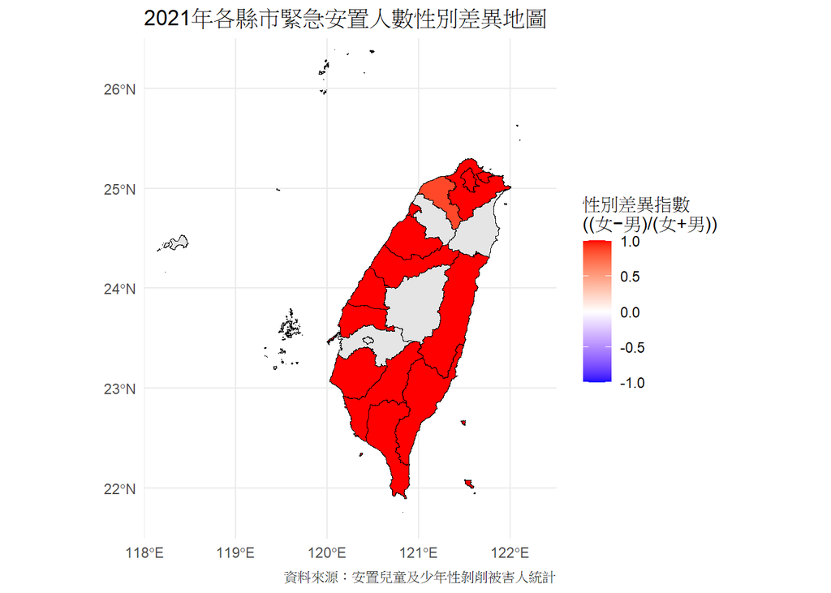

```r
library(ggplot2)

ggplot(map_data) +
  geom_sf(aes(fill = diff_index), color = "black", size = 0.000000001,na.rm = FALSE) +
  scale_fill_gradient2(
    low = "blue", high = "red", mid = "white",
    midpoint = 0, na.value = "gray90",
    limits = c(-1,1),
    name = "性別差異指數\n((女−男)/(女+男))"
  ) +
  labs(
    title = "2021年各縣市緊急安置人數性別差異地圖",
    caption = "資料來源：安置兒童及少年性剝削被害人統計"
  ) +
  theme_minimal()+
    coord_sf(xlim = c(118, 122.5), ylim = c(21.5, 26.5), expand = FALSE)
```

此地圖以性別差異指數 ((女−男)/(女+男))呈現各縣市在兒少性剝削被害人緊急安置上的性別分布。紅色代表女性比例高、藍色代表男性比例高，灰色則表示當年度該縣市無安置紀錄。

### 2021年各縣市緊急安置人數（依性別）

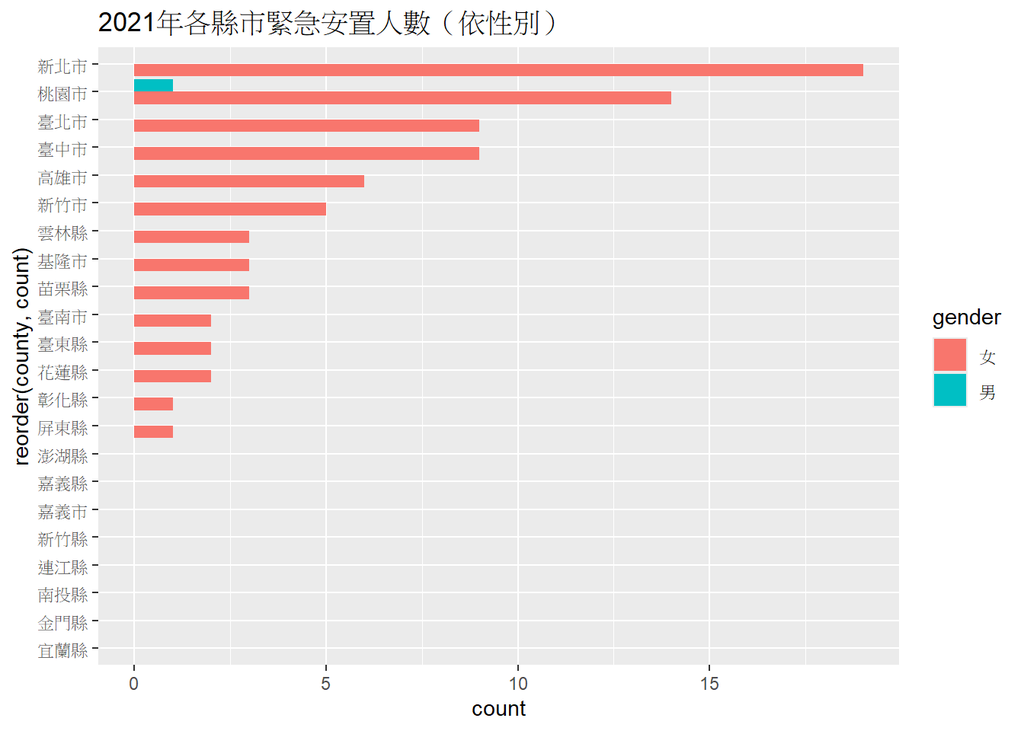

```r
df_2021_long <- df_emer_place %>%
  filter(year == 2021) %>%
  pivot_longer(cols = c("男", "女"), names_to = "gender", values_to = "count")

ggplot(df_2021_long, aes(x = reorder(county, count), y = count, fill = gender)) +
  geom_col(position = "dodge") +
  coord_flip() +
  labs(title = "2021年各縣市緊急安置人數（依性別）")
```

可從此圖觀察到多數縣市僅有女性被安置，顯示性別差異極高。僅有桃園市出現個別男性通報，其他多數縣市男性人數為0。

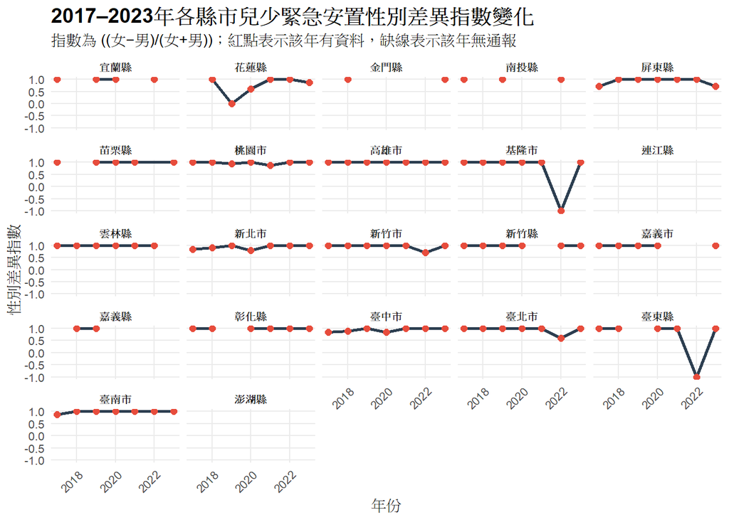

```r
ggplot(df_emer_place, aes(x = year, y = diff_index)) +
  geom_line(color = "#2C3E50", linewidth = 1, na.rm = FALSE) +
  geom_point(size = 2, color = "#E74C3C") +
  facet_wrap(~ county, ncol = 5) +
  labs(
    title = "2017–2023年各縣市兒少緊急安置性別差異指數變化",
    subtitle = "指數為 ((女−男)/(女+男))；紅點表示該年有資料，缺線表示該年無通報",
    x = "年份", y = "性別差異指數"
  ) +
  scale_y_continuous(limits = c(-1, 1)) +
  theme_minimal(base_size = 10) +
  theme(
    strip.text = element_text(face = "bold"),
    axis.text.x = element_text(angle = 45, hjust = 1),
    plot.title = element_text(size = 14, face = "bold"),
    plot.subtitle = element_text(size = 10),
    panel.grid.minor = element_blank()
  )
```

本圖呈現2017至2023年間各縣市緊急安置案件的性別差異指數變化，指數計算方式為 (女−男)/(女+男)。紅點表示該年有安置紀錄，線條連接指數可計算的年度。大多數縣市長年顯示出女性明顯多於男性的安置比例，部分縣市則出現劇烈波動，反映件數稀少或性別比例不穩。此圖亦可觀察制度是否在不同地區呈現執行落差或性別偏差的現象。

## 結果詮釋（Finding）

從 2021 年的資料來看，兒少性剝削被害人的緊急安置呈現明顯的性別落差，全台僅桃園市有男性安置個案，其餘縣市安置者幾乎全為女性。此外，更有包括連江縣、金門縣、宜蘭縣等 8 個縣市在該年度完全無通報紀錄。

這樣的現象顯示，兒少性剝削案件的通報與安置制度在實際執行過程中，可能因地區差異而呈現不一致的啟動標準與性別認知的偏差。雖然緊急安置制度原本設計為所有受害兒少所用，但在實務上，卻可能因資源分布不均或性別刻板印象，導致安置的處置主要執行於女性，男性兒少相對來說較為隱形。而從2017–2023年各縣市兒少緊急安置性別差異指數變化可看到，大多數縣市也長期呈現「僅有女性通報」的狀況。

除了制度上的漏接外，不排除男性兒少在性剝削案件中的實際案量原本就較低，不過此一差異可能與男性較不易被視為受害者、較難向他人揭露、通報意願低等社會性別因素相關，因此在解讀性別差異時，須回到社會結構因素進行分析。